# Assigment 5 Data Mining

Nathan Colbert

12/4/2017

# Smooth Nonlinear Models for a Continuous Outcome

```r
set.seed(1460345448)

mark2 <- colSums(is.na(College) == 0)

mark2 <- sapply(College, FUN = is.numeric)

mark2["Private"] <- FALSE

mark2
```

```
##     Private        Apps      Accept      Enroll   Top10perc   Top25perc
##       FALSE        TRUE        TRUE        TRUE        TRUE        TRUE
## F.Undergrad P.Undergrad    Outstate  Room.Board       Books    Personal
##        TRUE        TRUE        TRUE        TRUE        TRUE        TRUE
##         PhD    Terminal   S.F.Ratio perc.alumni      Expend   Grad.Rate
##        TRUE        TRUE        TRUE        TRUE        TRUE        TRUE
```

```r
College <- College [, mark2]

o_state <- createDataPartition(College$Outstate, times = 1, p = 3/4,
                               list = FALSE)

training <- College[o_state, ]

testing <- College[-o_state, ]
```

```r
colnames(training)
```

```
##  [1] "Apps"        "Accept"      "Enroll"      "Top10perc"   "Top25perc"
##  [6] "F.Undergrad" "P.Undergrad" "Outstate"    "Room.Board"  "Books"
## [11] "Personal"    "PhD"         "Terminal"    "S.F.Ratio"   "perc.alumni"
## [16] "Expend"      "Grad.Rate"
```

```r
oos_lm <- lm(Outstate ~ (. - Personal - perc.alumni - Expend) ^ 2,
             data = training, y = TRUE)

oos_lm2 <- lm(Outstate ~ poly(Accept, 4) + Top10perc + Top25perc + PhD
              + S.F.Ratio + Expend, data = training, y = TRUE)

oos_lm3 <- lm(Outstate ~ Accept + Accept * Enroll + Top10perc + PhD
              + S.F.Ratio + PhD * S.F.Ratio + perc.alumni, data = training,
              y = TRUE)

oos_lm4 <- lm(Outstate ~ (.) ^ 2, data = training, y = TRUE)

oos_lm5 <- lm(Outstate ~ (. - Personal - perc.alumni - Expend - Books - Enroll) ^ 2,
              data = training, y = TRUE)

oos_lm6 <- lm(Outstate ~ (. - Personal - perc.alumni - Expend - Books - Enroll
                          - PhD - Room.Board) ^ 2 + poly(Room.Board, 3)
              + poly(PhD, 2) + poly(Expend, 4) ,
              data = training, y = TRUE)

MSE_lm <- mean((testing$Outstate - predict(oos_lm, newdata = testing)) ^ 2)

MSE_lm2 <- mean((testing$Outstate - predict(oos_lm2, newdata = testing)) ^ 2)

MSE_lm3 <- mean((testing$Outstate - predict(oos_lm3, newdata = testing)) ^ 2)

MSE_lm4 <- mean((testing$Outstate - predict(oos_lm4, newdata = testing)) ^ 2)

MSE_lm5 <- mean((testing$Outstate - predict(oos_lm5, newdata = testing)) ^ 2)

MSE_lm6 <- mean((testing$Outstate - predict(oos_lm6, newdata = testing)) ^ 2)

c(MSE_lm, MSE_lm2, MSE_lm3, MSE_lm4, MSE_lm5, MSE_lm6)
```

```
## [1] 6421265 8270161 6795614 5653451 5158758 4759789
```

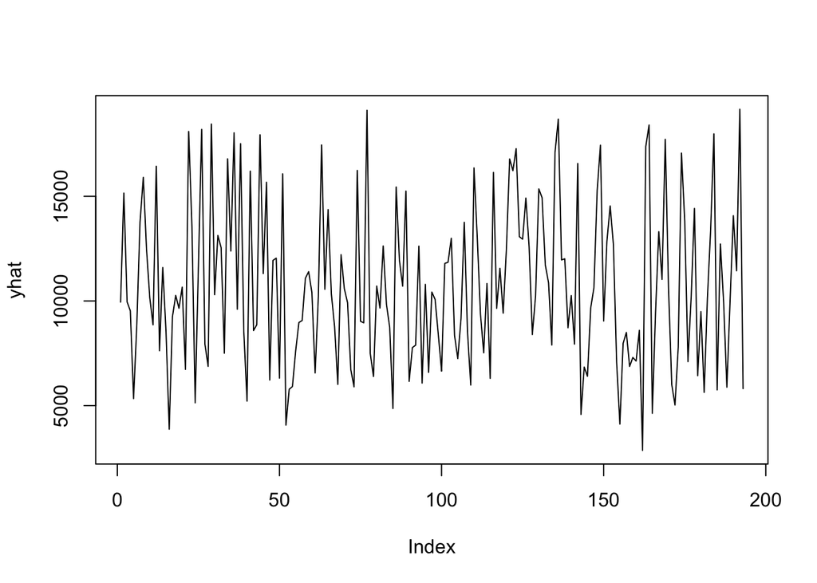

```r
oos_gam <- gam(Outstate ~ (. - Personal - perc.alumni - Expend - Books - Enroll
                           - PhD - Room.Board) ^ 2 + s(Room.Board, 3) + s(PhD, 2)
               + s(Expend, 4) , data = training, y = TRUE)

yhat <- predict(oos_gam, newdata = testing)

plot(yhat, type = "l")
```

4. From the variables I chose, Expend, Room.Board, and PhD, exhibit non linear relationships with Outstate (4, 3, 2, respectively). When they were made into higher order functions instead of linear functions, the overall standard error decreased beyond including them or interacting them as linear terms.

```r
MSE_gam <- mean((testing$Outstate - predict(oos_gam, newdata = testing)) ^ 2)

c(MSE_lm6, MSE_gam)
```

```
## [1] 4759789 4671068
```

```r
((MSE_lm6 - MSE_gam) / MSE_lm6) * 100
```

```
## [1] 1.863988
```

In this instance, the gam model predicts nearly 2% better than the linear model.

## Fused Lasso Additive Model

1. A fused lasso additive model is an estimated piece wise function where the knots are adaptable to whatever data set one is using.

```r
fl_y <- training$Outstate

fl_x <-training[, -8]

fl_testx <- testing[, -8]

colnames(fl_x)
```

```
##  [1] "Apps"        "Accept"      "Enroll"      "Top10perc"   "Top25perc"
##  [6] "F.Undergrad" "P.Undergrad" "Room.Board"  "Books"       "Personal"
## [11] "PhD"         "Terminal"    "S.F.Ratio"   "perc.alumni" "Expend"
## [16] "Grad.Rate"
```

```r
oos_flam <- flam(fl_x, fl_y)

alpha <- oos_flam$all.alpha[50]

lambda <- oos_flam$all.lambda[50]

MSE_flam <- mean((testing$Outstate - predict(oos_flam, new.x = fl_testx,
                                             lambda = lambda, alpha = alpha)) ^ 2)

c(MSE_lm6, MSE_gam, MSE_flam)
```

```
## [1] 4759789 4671068 4488492
```

```r
((MSE_gam - MSE_flam) / MSE_gam) * 100
```

```
## [1] 3.908654
```

It appears in this case, with this set of predictors, the flam model has the lowest mean squared error in the testing data. It performs approximately 4% better than the gam model.

## Tree-Based Models for a Binary Outcome

```r
load("~/Desktop/dataset5.RData")

mark3 <- colSums(is.na(dataset5) == 0) & sapply(dataset5, FUN = is.numeric)

dataset5 <- dataset5[, mark3]

dataset5$y <- factor(dataset5$y, levels = 0:1, labels = c("default", "paid"))


d5_split <- createDataPartition(dataset5$y, p = 3/4, list = FALSE)

d5_training <- dataset5[d5_split, ]

d5_testing <- dataset5[-d5_split, ]
```

```r
d5_glm <- glm(y ~ (.) ^ 2, data = d5_training,
              family = binomial(link = "logit"), y = TRUE)

yhat_glm <- predict(d5_glm, newdata = d5_testing, type = "response")

zhat_glm <- as.integer(yhat_glm > .05)
```

```r
bagged <- randomForest(y ~ (.) ^ 2, data = d5_training,
                       na.action = na.exclude,
                       importance = TRUE)

set_bart_machine_num_cores(parallel::detectCores())
```

```
## bartMachine now using 8 cores.
```

```r
colnames(d5_training)
```

```
##  [1] "loan_amnt"        "int_rate"         "installment"
##  [4] "emp_length"       "annual_inc"       "delinq_2yrs"
##  [7] "earliest_cr_line" "inq_last_6mths"   "open_acc"
## [10] "pub_rec"          "revol_bal"        "total_acc"
## [13] "y"
```

```r
bart <- bartMachine(X = d5_training[, -13], y = d5_training$y,
                    replace_missing_data_with_x_j_bar = TRUE,
                    mem_cache_for_speed = FALSE)
```

```
## bartMachine initializing with 50 trees...
## bartMachine vars checked...
## bartMachine java init...
## bartMachine factors created...
## Imputed missing data using attribute averages.
## bartMachine before preprocess...
## bartMachine after preprocess... 13 total features...
## bartMachine sigsq estimated...
## bartMachine training data finalized...
## Now building bartMachine for classification ...
## evaluating in sample data...done
```

```r
bart$confusion_matrix
```

```
##                predicted default predicted paid model errors
## actual default          6425.000          2.000        0.000
## actual paid             1070.000          4.000        0.996
## use errors                 0.143          0.333        0.143
```

```r
bagged$confusion
```

```
##         default paid class.error
## default    6266    9 0.001434263
## paid       1024    4 0.996108949
```

```r
table(d5_testing$y, zhat_glm)
```

```
##          zhat_glm
##              0    1
##   default  313 1767
##   paid      14  324
```